# EDA_report

Capstone 2 first report

Client: Light rail network (Data and Client are confidential)

Problem Statement:

Business Problem: Track and switch maintenance is currently reactive which leads to service outages, increased community impact and significant expense due to replacement of parts that undergo accelerated degradation when operated in substandard condition.

Proposed solution: Condition monitoring, if the areas of the network that are in need of maintenance can be detected before failure then preventative maintenance could be performed extending the lifetime of the network components and reducing the community impact and service outages.

Data Science Problem: Data of the network condition is collected weekly, however, there is currently no means of automated analysis, there is no temporal comparison. Consequently the X (usually 20) largest events are assessed by hand and the rest of the data is ignored. The client would like to assess track condition directly from the acceleration data without having to access the train control system to obtain train locations.

Data Science Solution: Build a model that integrates all data streams, identifies individual track locations and monitors the condition of those locations over time and flags any sections that are degraded past a given threshold.

This will take place in two stages, for the first stage we will build a model that predicts the train locations, once that model is working a second model and further data will be used to build a model that assess track condition and identifies track sections in need of maintenance.

Data:

Data Description: The dataset is a single lap of the complete network. The primary data is obtained by measuring the vertical acceleration of each side of the front axle on a train. As the axel is one piece these measurements are only partially independent as vibration can be transmitted from one side through the axel. The data collection setup is completely separate from the train command and control system and is manually initiated before the automated test train is dispatched. The data recorder is retrieved after the test train completes the circuit of the track network. The secondary data is a GPS trace of the network during the test circuit. The labels are the event log files pertaining to the test train from the command and control network.

While the accelerometer data, GPS trace and event log have time stamps these are not synchronised and have substantially different temporal resolution. The event log data is reported to the nearest second while the accelerometer is reported to the nearest ten thousandth of a second. The acceleration data begins at 10:05 AM and goes to 13:19 PM for 194 minutes of data. The GPS trace has no universal time reference but goes for 11666079 milliseconds, or 194 minutes. The first logged event in the label stream occurs at 10:31:11AM and the last event occurs at 13:16:44 PM spanning 165 minutes.

```python
import pandas as pd
import matplotlib.pyplot as plt
import seaborn as sb
import numpy as np
import os
import re
import scipy as sci

home = os.getcwd()
os.getcwd()

files = os.listdir()
csv_files = []
for n in files:
    if re.search(".csv", n):
        csv_files.append(n)

df = pd.read_csv(csv_files[0], header=15, names=["time", "acceleration_a"])
df.head()
df2 = pd.read_csv(csv_files[1], header=15, names=["time", "acceleration_b"])
df2.head()
raw = pd.merge(left=df, right=df2, how = "outer")
raw.tail()
# An example of the tail of the combined (both accelerometers) raw acceleration data
```

|  | time | acceleration_a | acceleration_b |
| --- | --- | --- | --- |
| 59744251 | 11668.7992 | 0.004007 | 0.001895 |
| 59744252 | 11668.7994 | 0.001367 | 0.001693 |
| 59744253 | 11668.7996 | 0.006664 | 0.002852 |
| 59744254 | 11668.7998 | 0.009457 | -0.006411 |
| 59744255 | 11668.8000 | 0.005155 | -0.003356 |

```python
df = pd.read_csv("../snoops.csv")
df["time"] = pd.to_datetime(df["Time"])
df4 = df.iloc[:4000, :]
df4 = df4.loc[df["Train Integrity"] == "Est"]
print(df.head())
print(df.tail())
# Likewise the head and tail of the raw labels data.
```

```
       Date      Time  VCC  CHN  Loop ID  Veh ID  Target Point  \
0  19/03/05  10:31:11    2    2        7     117           430
1  19/03/05  10:31:11    2    3        7     117           430
2  19/03/05  10:31:11    2    2        7     117           430
3  19/03/05  10:31:12    2    3        7     117           430
4  19/03/05  10:31:12    2    2        7     117           430

  Commanded Direction Door Cmd  Max Vel  ... Actual Velocity Type AB  \
0                 GD1   Closed       25  ...            24.0     NaN
1                 GD1   Closed       25  ...             0.0     NaN
2                 GD1   Closed       25  ...            24.0     NaN
3                 GD1   Closed       25  ...             0.0     NaN
4                 GD1   Closed       25  ...            25.0     NaN

   Veh ID.1 Special Message Previous Loop ID  Prev Entry Dir No Rx  \
```

[output cut: 43 more lines]

No data cleaning was performed on the acceleration data. For the labels the data was filtered by the vehicle of interest (117) and on train integrity (Est) then all columns were discarded except time, actual velocity, track section, GW Area and the datetime. This network is speed limited to 90 km/hr with a normal high of ~82 k/hr so any speeds in excess of 90 km/hr were discarded. Finally, any duplicates or NaN were dropped.In this process ~16300 entries were discarded but the time span remains the same.

```python
print(df.shape)
dfi = df.loc[df["Veh ID"] == 117,:]
print(dfi.shape)
dfg = dfi.loc[dfi["Train Integrity"] == "Est",:]
print(dfg.shape)
df5 = dfg.loc[:,["Time", "Actual Velocity", "Track Section", "GW Area", "time"]]
df5 = df5.loc[df5["Actual Velocity"] <= 90, :]
df5 = df5.drop_duplicates()
df5 = df5.dropna()
print(df5.shape)
print(df5.head())
print(df5.tail())
print(df5.describe())
```

```
(32947, 41)
(23530, 41)
(22991, 41)
(16688, 5)
        Time  Actual Velocity  Track Section     GW Area                time
0   10:31:11             24.0              0    ~OMC I/B 2021-04-05 10:31:11
4   10:31:12             25.0              0    ~OMC I/B 2021-04-05 10:31:12
9   10:31:13             25.0              0    ~OMC I/B 2021-04-05 10:31:13
12  10:31:13             25.0           2580  OMC Pocket 2021-04-05 10:31:13
14  10:31:14             25.0           2580  OMC Pocket 2021-04-05 10:31:14
           Time  Actual Velocity  Track Section   GW Area                time
32935  13:16:41             14.0              0  SL to Ex 2021-04-05 13:16:41
32937  13:16:42             14.0              0  SL to Ex 2021-04-05 13:16:42
32941  13:16:42             15.0              0  SL to Ex 2021-04-05 13:16:42
32942  13:16:43             15.0              0  SL to Ex 2021-04-05 13:16:43
32944  13:16:44             15.0              0  SL to Ex 2021-04-05 13:16:44
       Actual Velocity  Track Section
count     16688.000000   16688.000000
mean         40.663291    3183.758749
std          28.459131    2105.666506
min           0.000000       0.000000
25%          14.000000     952.750000
50%          43.000000    2881.000000
75%          67.000000    5293.250000
max          81.000000    6315.000000
```

To better understand the distribution of speeds a histogram was plotted. This histogram shows a bimodal distribution which would be expected as ideally the train is either a) at a station, b) moving as rapidly as possible to the next station.

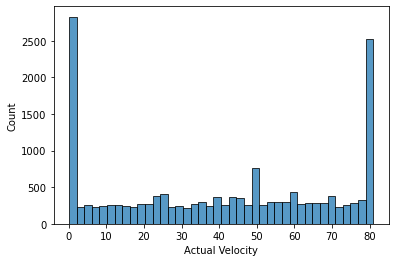

```python
sb.histplot(data=df5, x = "Actual Velocity", bins = 40)
plt.savefig("speed_hist.png")
plt.show()
```

The corresponding histogram for the track section data. This is a somewhat arbitrary numbering of the sections of track around the network.it is important to note that the train passes between several stations in both ways, with each direction being on separate track with a separate track number, this also corresponds to the difference in the final letter of the GW Area column (I for inbound O for outbound)

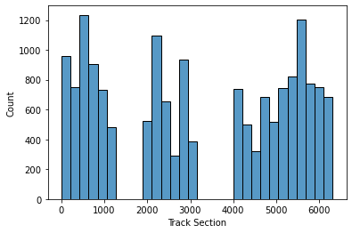

```python
sb.histplot(data=df5, x = "Track Section", bins = 30)
plt.savefig("track_num_hist.png")
plt.show()
```

No correlation between track section and velocity is expected, while a given track section may have a typical speed depending on proximity to station etc acroos a broad range of track number s a broad range of velocities is expected which is seen in the 2D histogram.

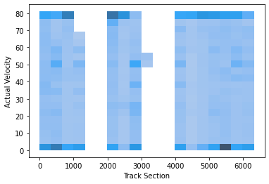

```python
sb.histplot(data=df5, x = "Track Section", y = "Actual Velocity")
plt.savefig("track_speed_hist.png")
plt.show()
```

This concludes the exploration of the labels data. The next step was to examine the raw acceleration data. It was immediately obvious that data recording commenced some time prior to the test run and that there were substantial negative values for the acceleration. Plotting a larger time period, the sensor data for both channels and the absolute value of acceleration gave a clearer picture of a test circuit.

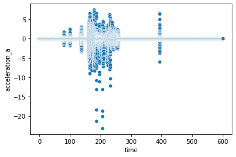

```python
a = sb.scatterplot(x="time", y="acceleration_a", data= raw.loc[raw.time<600,:])
```

```
['acceleration_a', 'acceleration_b']
```

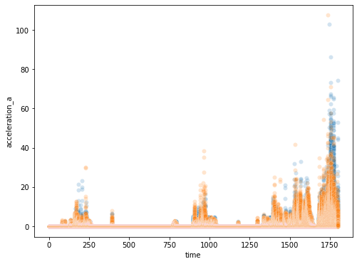

```python
cols = list(raw.columns)
cols.remove("time")
print(cols)
plt.figure(figsize=(8,6))
for n in cols:
    e = sb.scatterplot(x="time", y=n, data=raw.loc[raw.time <1800,:].abs(), alpha=0.2)
plt.show()
```

These plots demonstrated the need to condense the data to match the temporal resolution of the labels. The first approach I examined was short window fourier transforms (SWFT). The SWFT method is used to deconvolute the frequency components of each time period that make up the signal.

```python
df = np.log(pd.read_csv("ft_first_3000.csv", index_col=0))
print(df.info())
print(df.describe())
df.head()
```

```
<class 'pandas.core.frame.DataFrame'>
Int64Index: 3000 entries, 0 to 2999
Columns: 512 entries, 0_a to 2550_b
dtypes: float64(512)
memory usage: 11.7 MB
None
               0_a         10_a         20_a         30_a         40_a  \
count  3000.000000  3000.000000  3000.000000  3000.000000  3000.000000
mean     -3.977617    -4.534742    -4.394930    -4.420977    -4.358297
std       0.928281     1.365172     1.812665     1.966791     2.141216
min      -5.560123    -6.603165    -6.887542    -7.144105    -7.314706
25%      -4.598714    -5.774298    -6.172199    -6.421350    -6.550283
50%      -4.338299    -4.914318    -4.368295    -4.148160    -3.760436
75%      -3.553874    -3.308932    -2.680399    -2.605302    -2.358165
max       0.709888     0.693416     0.607406     0.483413     0.283324

              50_a         60_a         70_a         80_a         90_a  ...  \
count  3000.000000  3000.000000  3000.000000  3000.000000  3000.000000  ...
mean     -4.117747    -4.488621    -4.504324    -4.515064    -4.599973  ...
std       1.850925     2.267578     2.385408     2.441769     2.431985  ...
min      -7.390023    -7.567075    -7.725587    -7.841046    -7.872844  ...
25%      -5.669043    -6.823307    -6.963459    -7.047906    -7.121616  ...
50%      -3.805211    -3.812574    -3.711913    -3.627030    -3.753820  ...
75%      -2.435033    -2.377319    -2.302587    -2.254007    -2.384576  ...
max       0.091884    -0.096729     0.119595     0.431629     0.358601  ...

            2460_b       2470_b       2480_b       2490_b       2500_b  \
count  3000.000000  3000.000000  3000.000000  3000.000000  3000.000000
mean     -6.347882    -6.348104    -6.362789    -6.380340    -6.388581
std       2.260425     2.258893     2.259873     2.267859     2.273088
min      -9.379249    -9.299772    -9.237860    -9.425102    -9.293693
25%      -8.601289    -8.610491    -8.627213    -8.652095    -8.669404
50%      -6.135401    -6.184951    -6.252741    -6.245269    -6.197117
75%      -3.986281    -4.007718    -4.027427    -4.032071    -4.001122
max      -1.464306    -1.632472    -1.659316    -1.545905    -1.548140

            2510_b       2520_b       2530_b       2540_b       2550_b
count  3000.000000  3000.000000  3000.000000  3000.000000  3000.000000
mean     -6.359610    -6.374840    -6.395767    -6.408723    -6.511641
std       2.249642     2.266672     2.286530     2.278330     2.275528
min      -9.395180    -9.218265    -9.356131    -9.407281    -9.393010
25%      -8.611009    -8.643033    -8.679884    -8.691855    -8.791198
50%      -6.178932    -6.268426    -6.228846    -6.217508    -6.398587
75%      -4.028054    -4.038809    -4.011261    -4.035110    -4.157156
max      -1.635134    -1.421384    -1.208245    -1.199729    -1.287970

[8 rows x 512 columns]
```

|  | 0_a | 10_a | 20_a | 30_a | 40_a | 50_a | 60_a | 70_a | 80_a | 90_a | ... | 2460_b | 2470_b | 2480_b | 2490_b | 2500_b | 2510_b | 2520_b | 2530_b | 2540_b | 2550_b |
| --- | --- | --- | --- | --- | --- | --- | --- | --- | --- | --- | --- | --- | --- | --- | --- | --- | --- | --- | --- | --- | --- |
| 0 | -4.675121 | -5.508993 | -5.924969 | -6.342217 | -6.547992 | -6.621989 | -6.909804 | -6.779909 | -6.832581 | -7.262316 | ... | -8.604272 | -8.727891 | -8.771557 | -8.842847 | -8.438669 | -8.827195 | -8.636617 | -8.718394 | -8.695207 | -8.513479 |
| 1 | -4.558515 | -5.954450 | -6.015987 | -6.433740 | -6.400945 | -6.750701 | -6.852366 | -6.872135 | -7.406730 | -6.952475 | ... | -8.823817 | -8.659821 | -8.671849 | -8.532777 | -8.543997 | -8.745435 | -8.637762 | -8.649802 | -8.389345 | -8.943561 |
| 2 | -4.400749 | -6.110133 | -6.347419 | -6.467390 | -6.827850 | -6.805806 | -6.876529 | -6.973495 | -7.030149 | -6.935787 | ... | -8.662725 | -8.514430 | -8.620796 | -8.510398 | -8.440587 | -8.350155 | -8.564305 | -8.876479 | -8.776386 | -9.293635 |
| 3 | -4.598627 | -6.155862 | -6.326891 | -6.566853 | -6.562134 | -6.608527 | -7.022356 | -6.769141 | -7.169782 | -7.220056 | ... | -8.641243 | -8.844128 | -8.430055 | -8.695215 | -8.405692 | -8.764824 | -8.670898 | -8.870559 | -8.277612 | -8.900824 |
| 4 | -4.292200 | -5.910196 | -6.357794 | -6.233043 | -6.645595 | -5.992077 | -6.090861 | -6.997519 | -7.133647 | -6.632708 | ... | -8.578027 | -8.593505 | -8.489584 | -8.775621 | -8.536640 | -8.803250 | -8.951614 | -8.603564 | -8.482036 | -8.739134 |

5 rows × 512 columns

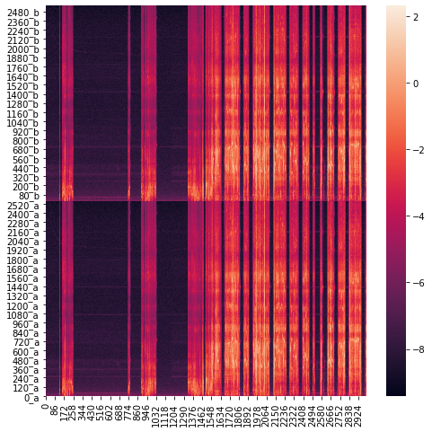

```python
plt.figure(figsize=(8,8))
ax = sb.heatmap(df.T)
ax.invert_yaxis()
plt.show()
```

Frequency components over time of the first 3000 seconds of acceleration data. The stationary periods are clear (large dark bands). However it is also clear there there is some noise in the signal (fine horizontal bands that persist through the stationary phases) as some frequencies are elevated at all times, these are likely to be due to background mechanical systems on the train (pumps/fans)

The test circuit resembles a normal passage of a train throughout the circuit. In practice the test train is interleaved into normal service with the exception that the train doors do not open at the stations (no passengers on board the test train). Using the knowledge of the route it was possible to identify the start of the circuit at ~1330 seconds, the first normal station stop at ~1482 seconds and the first terminus at ~2489 seconds. Thus the first ~1300 seconds of acceleration data represents the train being moved throughout the staging yard in preparation of the test circuit. The terminus can be identified by the characteristic symmetry in the signals between 2460 and 2640 seconds as well as by counting stations. Plotting the initial section of the test circuit illustrates that there are speed specific features in the SWFT

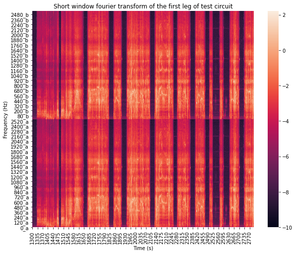

```python
plt.figure(figsize=(10,8))
f = sb.heatmap(df.iloc[1300:2800,:].T, vmin=-10, vmax=2.2)
f.invert_yaxis()
f.set_title("Short window fourier transform of the first leg of test circuit")
f.set_xlabel("Time (s)")
f.set_ylabel("Frequency (Hz)")
plt.show()
f.figure.savefig("first_leg_a.png")
```

After examining the SWFT it is clear that the stationary periods are human detectable and should be amenable to classification. Furthermore there appears to be some speed dependent signal particularly in the 300-750 Hz band and to a lesser degree in the 750-1650 Hz band.

As a comparison a plot of the first 4000 velocity labels is provided. Due to the nature of the train control software the sampling rate is variable. It appears that the symmetrical pattern that occurs in the acceleration data centered at 2540 seconds occurs at ~10:47 in the labels.

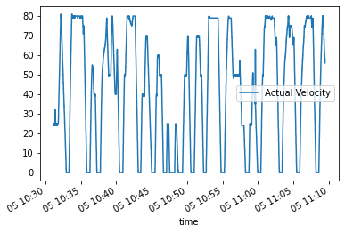

```python
plt.figure(figsize=(10,8))
df5.iloc[:4000,:].plot(x="time", y= "Actual Velocity")
plt.show()
```

Focussing on the symmetrical period in both data and reducing the range of the colour axis to enhance contrast some correlation between frequency intensity and speed is apparent. As speed increases overall vibration increases but also the dominant frequency (the highest decibel frequency) increases. Also noticeable are some broadband spikes where all frequencies are suddenly elevated, it is thought that these may correspond impacts and are likely to be pronounced track defects.

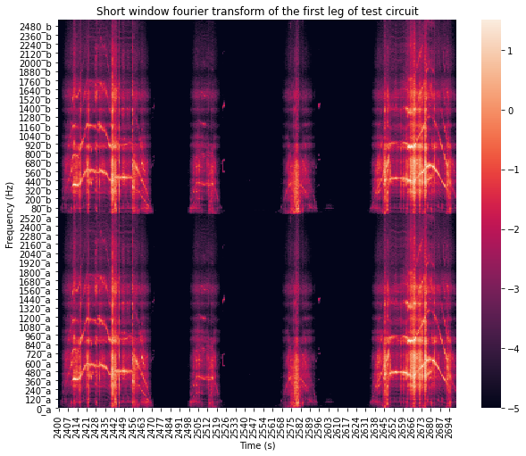

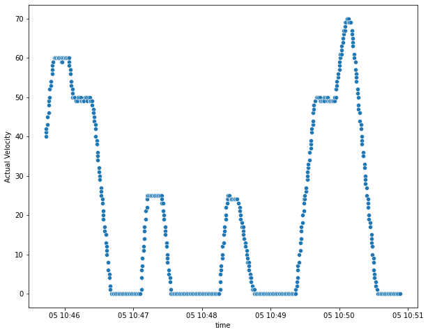

```python
plt.figure(figsize=(10,8))
f = sb.heatmap(df.iloc[2400:2700,:].T, vmin=-5, vmax=1.5)
f.invert_yaxis()
f.set_title("Short window fourier transform of the first leg of test circuit")
f.set_xlabel("Time (s)")
f.set_ylabel("Frequency (Hz)")
plt.show()
plt.figure(figsize=(10,8))
sb.scatterplot(data = df5.iloc[1550:2040,:], x = "time", y = "Actual Velocity")
plt.show()
```

Thus it should be possible to develop a model using the speed labels and the acceleration data to predict the current speed of the train. Integrating this data over time will give the distance the train has traveled which combined with the fixed route map and should allow the development of a positional model.